# EDA

## Exploratory Data Analysis

This notebook conduct EDA on the COVID-19 research paper dataset. The dataset is already cleaned from previous step

```python
#Import Libraries
try:
    %load_ext autotime
except:
    !pip install ipython-autotime
    %load_ext autotime

import csv
import random
import numpy as np
import pandas as pd

# Plotting
import matplotlib.pyplot as plt
import seaborn as sns

# Load word processing libraries
import re
import unicodedata
import nltk
from nltk.stem import WordNetLemmatizer
from nltk.corpus import stopwords
from nltk.tokenize import RegexpTokenizer
from nltk.tokenize import word_tokenize
nltk.download('stopwords')
nltk.download('wordnet')
nltk.download('punkt')
from wordcloud import WordCloud

# Machine Learning
# from sklearn.preprocessing import normalize
# import scipy.cluster.hierarchy as sch
# from sklearn.feature_extraction.text import TfidfVectorizer, CountVectorizer
# from sklearn.model_selection import train_test_split
# from sklearn.metrics import accuracy_score, f1_score, roc_curve, auc, roc_auc_score, classification_report
# from sklearn.manifold import TSNE
# from sklearn.decomposition import PCA
# from sklearn.cluster import KMeans, MiniBatchKMeans
# from sklearn.decomposition import LatentDirichletAllocation
# from sklearn.linear_model import SGDClassifier

import warnings
warnings.filterwarnings('ignore')
%matplotlib inline
```

```
The autotime extension is already loaded. To reload it, use:
  %reload_ext autotime
time: 297 ms
```

# Load Data

```python
df = pd.read_csv('../data/metadata.csv')
# df = df.sample(n=1000, random_state=1)
df.info(verbose=True)
df.head()
```

```
<class 'pandas.core.frame.DataFrame'>
RangeIndex: 536817 entries, 0 to 536816
Data columns (total 19 columns):
 #   Column            Non-Null Count   Dtype
---  ------            --------------   -----
 0   cord_uid          536817 non-null  object
 1   sha               180066 non-null  object
 2   source_x          536817 non-null  object
 3   title             536570 non-null  object
 4   doi               295050 non-null  object
 5   pmcid             191123 non-null  object
 6   pubmed_id         254917 non-null  object
 7   license           536817 non-null  object
 8   abstract          390379 non-null  object
 9   publish_time      536598 non-null  object
 10  authors           522082 non-null  object
 11  journal           501591 non-null  object
 12  mag_id            0 non-null       float64
 13  who_covidence_id  222762 non-null  object
 14  arxiv_id          6996 non-null    object
 15  pdf_json_files    180066 non-null  object
 16  pmc_json_files    147047 non-null  object
 17  url               315683 non-null  object
 18  s2_id             488029 non-null  float64
dtypes: float64(2), object(17)
memory usage: 77.8+ MB
```

|  | cord_uid | sha | source_x | title | doi | pmcid | pubmed_id | license | abstract | publish_time | authors | journal | mag_id | who_covidence_id | arxiv_id | pdf_json_files | pmc_json_files | url | s2_id |
| --- | --- | --- | --- | --- | --- | --- | --- | --- | --- | --- | --- | --- | --- | --- | --- | --- | --- | --- | --- |
| 0 | ug7v899j | d1aafb70c066a2068b02786f8929fd9c900897fb | PMC | Clinical features of culture-proven Mycoplasma... | 10.1186/1471-2334-1-6 | PMC35282 | 11472636 | no-cc | OBJECTIVE: This retrospective chart review des... | 2001-07-04 | Madani, Tariq A; Al-Ghamdi, Aisha A | BMC Infect Dis | NaN | NaN | NaN | document_parses/pdf_json/d1aafb70c066a2068b027... | document_parses/pmc_json/PMC35282.xml.json | https://www.ncbi.nlm.nih.gov/pmc/articles/PMC3... | NaN |
| 1 | 02tnwd4m | 6b0567729c2143a66d737eb0a2f63f2dce2e5a7d | PMC | Nitric oxide: a pro-inflammatory mediator in l... | 10.1186/rr14 | PMC59543 | 11667967 | no-cc | Inflammatory diseases of the respiratory tract... | 2000-08-15 | Vliet, Albert van der; Eiserich, Jason P; Cros... | Respir Res | NaN | NaN | NaN | document_parses/pdf_json/6b0567729c2143a66d737... | document_parses/pmc_json/PMC59543.xml.json | https://www.ncbi.nlm.nih.gov/pmc/articles/PMC5... | NaN |
| 2 | ejv2xln0 | 06ced00a5fc04215949aa72528f2eeaae1d58927 | PMC | Surfactant protein-D and pulmonary host defense | 10.1186/rr19 | PMC59549 | 11667972 | no-cc | Surfactant protein-D (SP-D) participates in th... | 2000-08-25 | Crouch, Erika C | Respir Res | NaN | NaN | NaN | document_parses/pdf_json/06ced00a5fc04215949aa... | document_parses/pmc_json/PMC59549.xml.json | https://www.ncbi.nlm.nih.gov/pmc/articles/PMC5... | NaN |
| 3 | 2b73a28n | 348055649b6b8cf2b9a376498df9bf41f7123605 | PMC | Role of endothelin-1 in lung disease | 10.1186/rr44 | PMC59574 | 11686871 | no-cc | Endothelin-1 (ET-1) is a 21 amino acid peptide... | 2001-02-22 | Fagan, Karen A; McMurtry, Ivan F; Rodman, David M | Respir Res | NaN | NaN | NaN | document_parses/pdf_json/348055649b6b8cf2b9a37... | document_parses/pmc_json/PMC59574.xml.json | https://www.ncbi.nlm.nih.gov/pmc/articles/PMC5... | NaN |
| 4 | 9785vg6d | 5f48792a5fa08bed9f56016f4981ae2ca6031b32 | PMC | Gene expression in epithelial cells in respons... | 10.1186/rr61 | PMC59580 | 11686888 | no-cc | Respiratory syncytial virus (RSV) and pneumoni... | 2001-05-11 | Domachowske, Joseph B; Bonville, Cynthia A; Ro... | Respir Res | NaN | NaN | NaN | document_parses/pdf_json/5f48792a5fa08bed9f560... | document_parses/pmc_json/PMC59580.xml.json | https://www.ncbi.nlm.nih.gov/pmc/articles/PMC5... | NaN |

```
time: 12.6 s
```

```python
# load the meta data from the CSV file and extract out fields that will be useful to our application
df = df[['title','abstract','authors','publish_time']]
df = df.drop_duplicates(subset='abstract', keep='first')
df = df.dropna()
df['abstract'] = df['abstract'].str.lower()
df.head()
```

|  | title | abstract | authors | publish_time |
| --- | --- | --- | --- | --- |
| 0 | Clinical features of culture-proven Mycoplasma... | objective: this retrospective chart review des... | Madani, Tariq A; Al-Ghamdi, Aisha A | 2001-07-04 |
| 1 | Nitric oxide: a pro-inflammatory mediator in l... | inflammatory diseases of the respiratory tract... | Vliet, Albert van der; Eiserich, Jason P; Cros... | 2000-08-15 |
| 2 | Surfactant protein-D and pulmonary host defense | surfactant protein-d (sp-d) participates in th... | Crouch, Erika C | 2000-08-25 |
| 3 | Role of endothelin-1 in lung disease | endothelin-1 (et-1) is a 21 amino acid peptide... | Fagan, Karen A; McMurtry, Ivan F; Rodman, David M | 2001-02-22 |
| 4 | Gene expression in epithelial cells in respons... | respiratory syncytial virus (rsv) and pneumoni... | Domachowske, Joseph B; Bonville, Cynthia A; Ro... | 2001-05-11 |

```
time: 3.92 s
```

In order to visualize the trend of published papers, we add a year column by extracting the year from the "publish time" column.

```python
# Add publish year feature
df.publish_time = pd.to_datetime(df['publish_time'],format='%Y-%m-%d', errors='coerce')
df['publish_year'] = pd.DatetimeIndex(df.publish_time).year
df.dtypes
```

```
title                   object
abstract                object
authors                 object
publish_time    datetime64[ns]
publish_year             int64
dtype: object
```

```
time: 203 ms
```

```python
df.shape
```

```
(341827, 5)
```

```
time: 0 ns
```

# Text Cleaning

Among the extracted features from the data, since the title of a scientific research paper is closely related to the abstract (or even just the same words from the abstract), we will look at the abstract only for preliminary analysis.

Using natural language toolkit (NLTK) stopwords, which include pronouns (such as 'i', 'we', 'she'), transitional words (such as 'the', 'and', 'if'), and other words that generally appear in scientific papers, we will eliminate some of the meaningless words in this context. This way, we can save space and extract meaningful words from text features for further analysis.

```python
# Using NLTK's list of stopwords
stopword_list = stopwords.words('english')
more_sw = ['doi', 'preprint', 'copyright', 'org', 'https', 'et', 'al', 'author',
           'figure', 'table', 'rights', 'reserved', 'permission', 'use', 'used',
           'using', 'biorxiv', 'medrxiv', 'license', 'fig', 'fig.', 'al.',
           'results', 'study', 'shown', 'based', 'found', 'could', 'observed',
           'cases', 'publisher', 'including', 'against', 'say', 'beyond', 'seem',
           'thereby', 'bottom', 'get', 'peer', 'review', 'permission', 'Elsevier',
           'PMC', 'CZI', 'may', 'also', 'due', 'however', 'within', 'del', 'las',
           'por', 'los', 'para', 'que', 'non', 'none', 'il', 'paper', 'undergo',
           'underwent', 'rt', 'les', 'number', 'numbers', 'propose', 'proposed',
           'one', 'two', 'three', 'assay', 'article', 'group', 'conclusion',
           'conclusions', 'nan', 'the']
for sw in more_sw:
    stopword_list.append(sw)
```

```
time: 0 ns
```

Before analysis and modeling, we need to clean the text features to make sure that the remaining words are meaningful.

The pipeline for cleaning the paper abstracts is as follows:

- Remove HTML tags and attributes;
- Replace HTML character codes with ASCII equivalents;
- Remove URLs;
- Remove new-line characters, punctuations, and extra white spaces;
- Lemmatization of remaining words;
- Remove stopwords.

For this step, I chose not to remove all non-letter characters (such as '-' and numbers) because of the following reasons:

- 'Covid-19' is expected to be one of the most important words in this project, it might be best to keep it as is;
- There will be a lot of scientific names for viral strings, chemical compounds, or protein structures, such as 'sp-d' or 'et-1', which could be important to the problem that we are trying to analyze;
- Most of the compounded words might not make sense after stripping away the numbers.

```python
lemmatizer = WordNetLemmatizer()

# Create function for cleaning the tweets column
def clean_abstract(s):
    s = str(s.lower())
    # Remove HTML tags and attributes from the string
    html_tags = re.compile('<.*?>')
    s = re.sub(html_tags, '', s)
    # Replace HTML character codes with ASCII equivalent
    s = unicodedata.normalize('NFKD', s).encode('ascii', 'ignore').decode('utf-8')
    # Remove URLs
    s = re.sub(r'http\S+', '', s)
    # Remove new line and line breaks characters
    s = s.replace('b"', '').replace("b'", '').replace('\n', '').replace('\\n', '').replace('\\n\\n', '').replace('\t', '')
    # Remove punctuations
    s = re.sub('[^a-zA-z0-9\s-]', ' ', s)
    # Replace extra white spaces with one space
    s = re.sub(r'\s+', ' ', s)
    # Lemmatization
    s = lemmatizer.lemmatize(s)
    # Remove stop words
    text_tokens = word_tokenize(s)
    s = [word for word in text_tokens if not word in stopword_list]
    # Remove words with only 2 letters or less
    s = [i for i in s if len(i) > 2]
    return ' '.join(s)
```

```
time: 0 ns
```

```python
# Perform data cleaning on the "abstract" feature
df_cleaned = df.copy(deep=True)
df_cleaned['abstract'] = df_cleaned['abstract'].apply(clean_abstract)
df_cleaned.head()
```

|  | title | abstract | authors | publish_time | publish_year |
| --- | --- | --- | --- | --- | --- |
| 0 | Clinical features of culture-proven Mycoplasma... | objective retrospective chart describes epidem... | Madani, Tariq A; Al-Ghamdi, Aisha A | 2001-07-04 | 2001 |
| 1 | Nitric oxide: a pro-inflammatory mediator in l... | inflammatory diseases respiratory tract common... | Vliet, Albert van der; Eiserich, Jason P; Cros... | 2000-08-15 | 2000 |
| 2 | Surfactant protein-D and pulmonary host defense | surfactant protein-d sp-d participates innate ... | Crouch, Erika C | 2000-08-25 | 2000 |
| 3 | Role of endothelin-1 in lung disease | endothelin-1 et-1 amino acid peptide diverse b... | Fagan, Karen A; McMurtry, Ivan F; Rodman, David M | 2001-02-22 | 2001 |
| 4 | Gene expression in epithelial cells in respons... | respiratory syncytial virus rsv pneumonia viru... | Domachowske, Joseph B; Bonville, Cynthia A; Ro... | 2001-05-11 | 2001 |

```
time: 10min 7s
```

## Detect Lanaugaes

In this section, we'll find if there're languages other than English. Then We will be dropping any language that is not English, since we don't have capacity to translation other languages to English.

```python
from tqdm import tqdm
from langdetect import detect
from langdetect import DetectorFactory

# set seed
DetectorFactory.seed = 0

# hold label - language
languages = []

# go through each text
for ii in tqdm(range(0,len(df))):
    # split by space into list, take the first x intex, join with space
    text = str(df.iloc[ii]['abstract']).split(" ")

    lang = "en"
    try:
        lang = detect(" ".join(text[:len(text)]))
    except Exception as e:
        lang = "unknown"

    # get the language
    languages.append(lang)
```

```
time: 1h 7s
```

```python
from pprint import pprint

languages_dict = {}
for lang in set(languages):
    languages_dict[lang] = languages.count(lang)

print("Total: {}\n".format(len(languages)))
pprint(languages_dict)
```

```
Total: 341827

{'af': 6,
 'bg': 11,
 'ca': 18,
 'cs': 1,
 'cy': 2,
 'da': 1,
 'de': 862,
 'en': 335715,
 'es': 2029,
 'et': 2,
 'fa': 2,
 'fi': 2,
 'fr': 1022,
 'hr': 3,
 'hu': 41,
 'id': 3,
 'it': 70,
 'ja': 8,
 'ko': 40,
 'lt': 1,
 'mk': 1,
 'nl': 258,
 'no': 4,
 'pt': 1122,
 'ro': 17,
 'ru': 298,
 'sl': 2,
 'so': 1,
 'sw': 1,
 'tl': 3,
 'tr': 27,
 'uk': 1,
 'unknown': 13,
 'vi': 3,
 'zh-cn': 236,
 'zh-tw': 1}
time: 234 ms
```

```python
df["language"] = languages
df = df[df['language'] == 'en']
df.info()
```

```
<class 'pandas.core.frame.DataFrame'>
Int64Index: 335715 entries, 0 to 536816
Data columns (total 6 columns):
 #   Column        Non-Null Count   Dtype
---  ------        --------------   -----
 0   title         335715 non-null  object
 1   abstract      335715 non-null  object
 2   authors       335715 non-null  object
 3   publish_time  335715 non-null  datetime64[ns]
 4   publish_year  335715 non-null  int64
 5   language      335715 non-null  object
dtypes: datetime64[ns](1), int64(1), object(4)
memory usage: 17.9+ MB
time: 1.17 s
```

# EDA and Data Visualizations

Out of the 335715 research papers left after removing duplicates and NAN values, it would be informative to look at the content and try to discover trends.

```python
# Function for counting unique strings in a column
def count_unique(df, col, delimiter):
    val_list = []
    for i in range(len(df)):
        val = df[col].iloc[i]
        split_val = val.split(delimiter)
        val_list.append(split_val)
    val_list = [item for sublist in val_list for item in sublist]
    num_unique = len(set(val_list))
    return num_unique
```

```
time: 0 ns
```

```python
# Count the number of unique authors in the data
count_unique(df_cleaned.dropna(subset=["authors"]), 'authors', ';')
```

```
1206127
```

```
time: 8.84 s
```

From the above pipeline, we can see that there are around 1206127 different authors contributing to this large corpus of Covid-19 related research papers. This indicates that there are roughly 3 to 4 authors contributing to each research paper, which is common in the medical field.

The large number of researchers is reassuring because we can see how the world's brightest minds are working together to study and solve Covid-19.

```python
# Create a new column containing the most frequent word in each abstract
from collections import Counter

def most_frequent(words):
    l = word_tokenize(words)
    data = Counter(l)
    try:
        return max(l, key=data.get)
    except:
        return ''

df_cleaned['most_frequent_word'] = df_cleaned.abstract.apply(most_frequent)
df_cleaned.head()
```

|  | title | abstract | authors | publish_time | publish_year | most_frequent_word |
| --- | --- | --- | --- | --- | --- | --- |
| 0 | Clinical features of culture-proven Mycoplasma... | objective retrospective chart describes epidem... | Madani, Tariq A; Al-Ghamdi, Aisha A | 2001-07-04 | 2001 | patients |
| 1 | Nitric oxide: a pro-inflammatory mediator in l... | inflammatory diseases respiratory tract common... | Vliet, Albert van der; Eiserich, Jason P; Cros... | 2000-08-15 | 2000 | evidence |
| 2 | Surfactant protein-D and pulmonary host defense | surfactant protein-d sp-d participates innate ... | Crouch, Erika C | 2000-08-25 | 2000 | sp-d |
| 3 | Role of endothelin-1 in lung disease | endothelin-1 et-1 amino acid peptide diverse b... | Fagan, Karen A; McMurtry, Ivan F; Rodman, David M | 2001-02-22 | 2001 | et-1 |
| 4 | Gene expression in epithelial cells in respons... | respiratory syncytial virus rsv pneumonia viru... | Domachowske, Joseph B; Bonville, Cynthia A; Ro... | 2001-05-11 | 2001 | respiratory |

```
time: 7min 54s
```

```python
# Show the most frequent words in all abstracts in this data
most_mentioned_words = df_cleaned.most_frequent_word.value_counts()[:15]
most_mentioned_words
```

```
covid-19       25439
patients       18059
sars-cov-2      7242
health          5570
pandemic        2940
disease         2773
care            2369
virus           2348
coronavirus     2087
respiratory     1907
data            1776
model           1729
infection       1697
children        1648
social          1635
Name: most_frequent_word, dtype: int64
```

```
time: 203 ms
```

By extracting the most frequent keywords from the abstracts, the trend of the research topics are becoming clear. From the above list, we can see that the Covid-19 (otherwise known sars-cov-2 or coronavirus) virus is causing a pandemic that infects the respiratory system of patients in a cellular level.

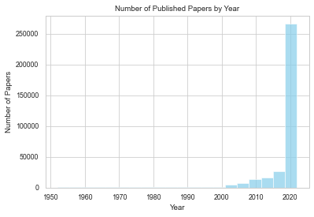

```
time: 6.78 s
```

```python
# Number of published paper by year
sns.set_theme(style='whitegrid')
sns.set_context('paper')
plt.hist(list(df['publish_year']), bins=20, alpha=0.7, color='skyblue')
plt.xlabel('Year')
plt.ylabel('Number of Papers')
plt.title('Number of Published Papers by Year')
```

From the above bar plot we can see that the amount of paper published (related to Covid-19) skyrocketed around 2020 because of the pandemic outbreak.

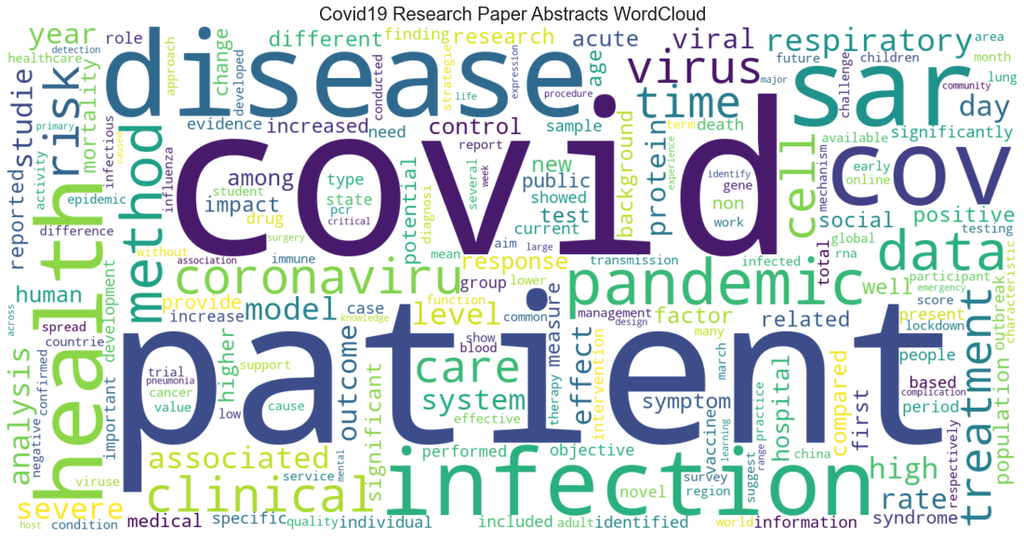

```
time: 2min 45s
```

```python
# Create word cloud for the abstracts
all_abstract = ' '.join(ab for ab in df_cleaned.abstract)
wordcloud_positive = WordCloud(width=1500, height=750, max_words=200,
                               background_color='white', collocations=False).generate(all_abstract)
plt.figure(figsize=(20, 10))
plt.imshow(wordcloud_positive, interpolation='bilinear')
plt.axis('off')
plt.title('Covid19 Research Paper Abstracts WordCloud', fontsize=20)
```

From the word cloud generated above, we start to see some levels of research directions in the papers:

- Covid, cov, coronavirus, sar
- Virus, infection, cell, protein, treatment (virus study)
- Mortality, death (death rate study)
- Respiratory, age, lung, blood, protein, risk (risk factor study and impact analysis)